# Lab 2

Katherine Goode, Ashish Jain, Haley Jeppson

February 2, 2017

Using tools from `dplyr` and `ggplot2` answer the following questions:

- What were the most successful movies over the past two years? Make sure to define how you measure success. What can you say about movies that only came out recently?
- How long, on average, are movies in theaters? Also look at the median time. Try to figure out what contributes to the big difference.
- What is the standard trajectory of a movie’s total gross? Draw a plot and label some of the trajectories.  
  If you feel ambitious, you could try to model this trajectory - but if you do, make sure to detail all assumptions that you make.

```r
movies <- read_csv(curl("https://raw.githubusercontent.com/Stat585-at-ISU/materials/master/data/movies.csv"))
head(movies)
```

```
## # A tibble: 6 × 12
##         Date  Rank Rank.Last.Week  Days                        Movie
##       <date> <int>          <int> <int>                        <chr>
## 1 2017-01-27     1              1    10                        Split
## 2 2017-01-27     2             NA     3              A Dog’s Purpose
## 3 2017-01-27     3              3    36               Hidden Figures
## 4 2017-01-27     4             NA     3 Resident Evil: The Final Ch…
## 5 2017-01-27     5              5    52                   La La Land
## 6 2017-01-27     6              2    10   xXx: Return of Xander Cage
## # ... with 7 more variables: Distributor <chr>, Gross <int>, Change <dbl>,
## #   Total.Gross <int>, Release <date>, Theaters <int>, Per.Theater <dbl>
```

#### 1. What were the most successful movies over the past two years? Make sure to define how you measure success. What can you say about movies that only came out recently?

Our first measure of success is the total gross of the movie. To find the total gross for a film, we found the maximum total gross recorded for each film. Below is a snippet of the top grossing films over the past two years.

```r
top <- movies %>% group_by(Movie) %>% filter(Days < 365*2)  %>% summarize(max.gross=max(Total.Gross)) %>% arrange(desc(max.gross))
head(top)
```

```
## # A tibble: 6 × 2
##                          Movie max.gross
##                          <chr>     <int>
## 1 Star Wars Ep. VII: The Forc… 936658640
## 2               Jurassic World 652177270
## 3 Rogue One: A Star Wars Story 520200086
## 4                 Finding Dory 486292984
## 5  The Avengers: Age of Ultron 458991599
## 6   Captain America: Civil War 408080554
```

To allow film released recently a chance to be considered a top film, we defined a second measure of success based on the total gross within the first 14 days of being released. The results from this second measure of success are slightly different from the first, but the top two films remain the same.

```r
movies %>% group_by(Movie) %>% filter(Days < 14)  %>% summarize(max.gross=max(Total.Gross)) %>% arrange(desc(max.gross)) %>% head()
```

```
## # A tibble: 6 × 2
##                          Movie max.gross
##                          <chr>     <int>
## 1 Star Wars Ep. VII: The Forc… 540058914
## 2               Jurassic World 402800095
## 3  The Avengers: Age of Ultron 313402397
## 4   Captain America: Civil War 295966220
## 5                 Finding Dory 286277856
## 6 Rogue One: A Star Wars Story 286033442
```

We could also define success as the greatest number of weeks in the top ten. However, this would again neglect movies that have recently been released. Interestingly, the results of this measure of success differ from both measures using total gross.

```r
movies %>% filter(Rank < 11) %>% group_by(Movie) %>% tally() %>% arrange(desc(n)) %>% head()
```

```
## # A tibble: 6 × 2
##                          Movie     n
##                          <chr> <int>
## 1                     Zootopia    13
## 2                         Home    10
## 3 Star Wars Ep. VII: The Forc…    10
## 4                 The Revenant    10
## 5               Jurassic World     9
## 6 Kingsman: The Secret Service     9
```

#### 2. How long, on average, are movies in theaters? Also look at the median time. Try to figure out what contributes to the big difference.

Calculate mean and median time spent in theaters:

```r
movies %>% group_by(Movie) %>% summarise(DaysInTheaters = max(Days)) %>% summarise(MeanDaysInTheaters = mean(DaysInTheaters), MedianDaysInTheaters = median(DaysInTheaters))
```

```
## # A tibble: 1 × 2
##   MeanDaysInTheaters MedianDaysInTheaters
##                <dbl>                <dbl>
## 1           278.1926                   47
```

Explore why the differences are so large:

```r
time <- movies %>% group_by(Movie) %>% summarize(DaysInTheaters=max(Days), release=Release[1]) %>% arrange(desc(DaysInTheaters))
head(time)
```

```
## # A tibble: 6 × 3
##                     Movie DaysInTheaters    release
##                     <chr>          <int>     <date>
## 1         The Fallen Idol          24478 1949-11-12
## 2           The Third Man          24035 1950-01-30
## 3 Elevator to the Gallows          20281 1961-06-07
## 4                  Marnie          18772 1963-12-29
## 5       Band of Outsiders          18409 1966-03-12
## 6   The Battle of Algiers          18016 1967-09-17
```

After sorting the movies based on the number of days it has been in theaters, we can see that the large difference is due to films released as early as 1949 being included in the dataset. We could look at a histogram of the the number of days spent in theaters and see that the distribution is very right skewed.

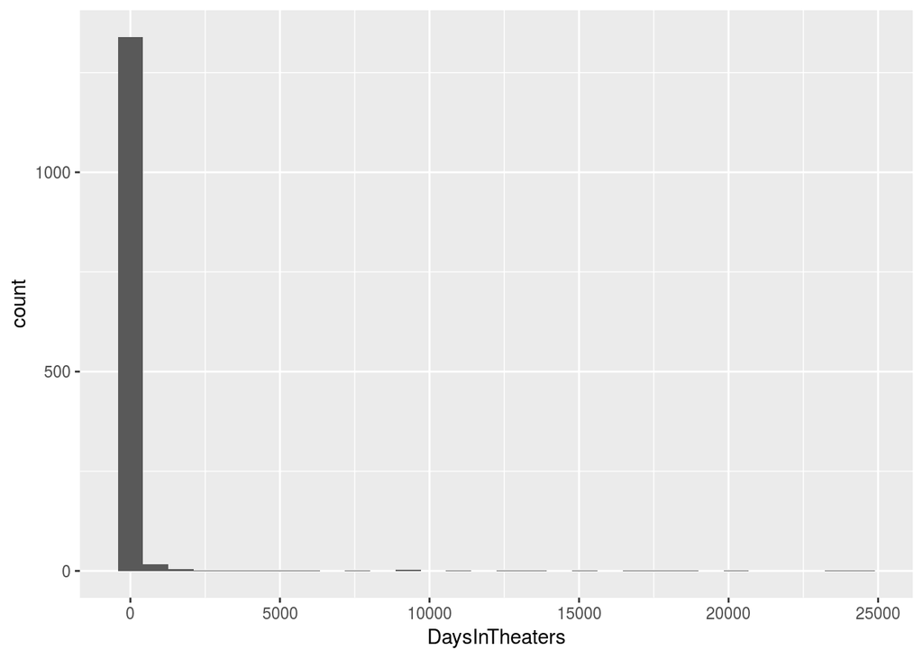

```r
time %>% ggplot(aes(DaysInTheaters)) + geom_histogram()
```

#### 3. What is the standard trajectory of a movie’s total gross? Draw a plot and label some of the trajectories. If you feel ambitious, you could try to model this trajectory - but if you do, make sure to detail all assumptions that you make.

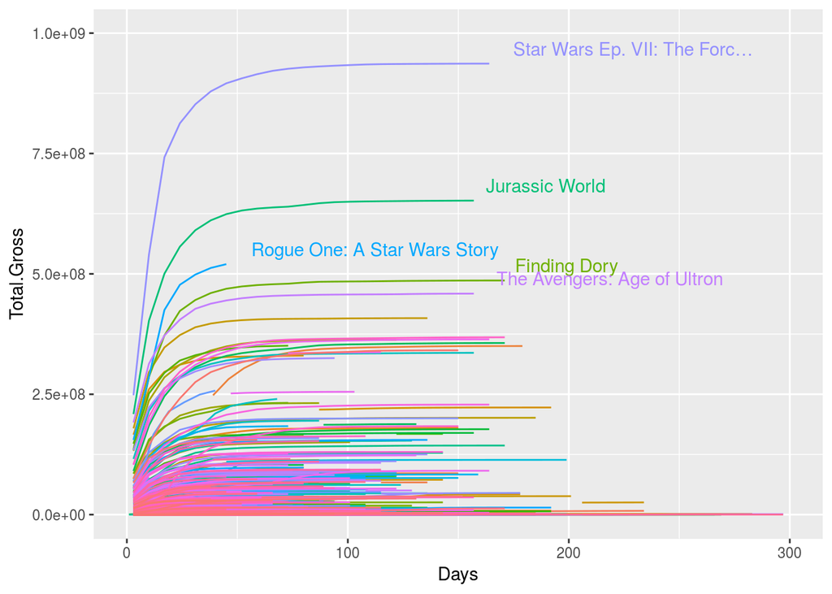

```r
movies %>% group_by(Movie) %>%
  mutate(appear.count = rank(Days)) %>%
  ggplot(aes(x=Days, y=Total.Gross, color=Movie)) +
  geom_line(aes(group=Movie)) +
  theme(legend.position = "none") + xlim(0,300) + ylim(0,1000000000)+
  geom_text(data = movies %>% group_by(Movie) %>% mutate(Total=max(Total.Gross)) %>% filter(Total.Gross == Total, Movie %in% head(top$Movie, n=5)), aes(label=Movie), vjust=-.6, hjust=-.1)
```